# Trabalho Final

Charlotte Junge

28/06/2019

O objetivo do trabalho e a previsão para os próximos dois períodos, considerando a tendência e sazonalidade se existir. A base da pesquisa e um conjunto de dados de vendas de materiais em construcao de 1960 ate 1972. Para cada ano, existem 4 valores, entao a frequencia da série temporal e igual a 4.

## Preparacao dos dados

Nao foi necessario fazer uma “limpeza” dos dados nesse caso, já que nao tinha valores absentes na base de dados, a organziacao foi feito de uma maneira coeerente assim que foi possivel importar ela diretamente no R e construir uma variavel do tipo ts.

```r
library(readr)
library(fpp2)
```

```r
library(ggplot2)
material <- read_csv("~/Documents/Bachelor/6. Semester/Estatística e Modelos de Previsao/material_construcao.csv")
material
```

```
## # A tibble: 52 x 2
##    index   value
##    <chr>   <dbl>
##  1 1960 Q1   242
##  2 1960 Q2   268
##  3 1960 Q3   290
##  4 1960 Q4   277
##  5 1961 Q1   241
##  6 1961 Q2   253
##  7 1961 Q3   265
##  8 1961 Q4   236
##  9 1962 Q1   229
## 10 1962 Q2   265
## # … with 42 more rows
```

```r
y <- ts(material$value, frequency=4, start=c(1960, 1))
```

## Explorar os dados

Para obter uma primeira impressao dos dados, plotam-se gráficos. Como pode-se observar existe uma tendencia crescente das vendas de materiais de construcao. Como cada ano vendem-se mais unidades. De igual forma, fica evidente que existem diferencas sistematicas entre Q1, Q2, Q3 e Q4 que se repitem cada ano. Nos ultimos dois trimestres de cada ano, as vendas sao especialmente altas. No primeiro semestre, elas chegam ao nivel mais baixo, o segundo semestre fica entre Q1 e Q3. Pode-se entao constatar a presencia de sazonalidade e tendência.

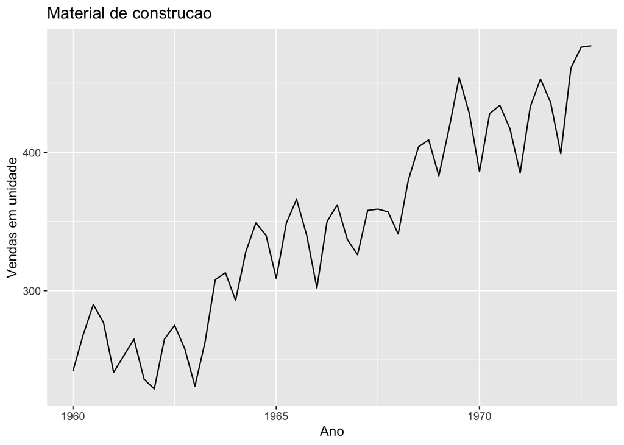

```r
autoplot(y) + ylab("Vendas em unidade") + xlab("Ano") + ggtitle("Material de construcao")
```

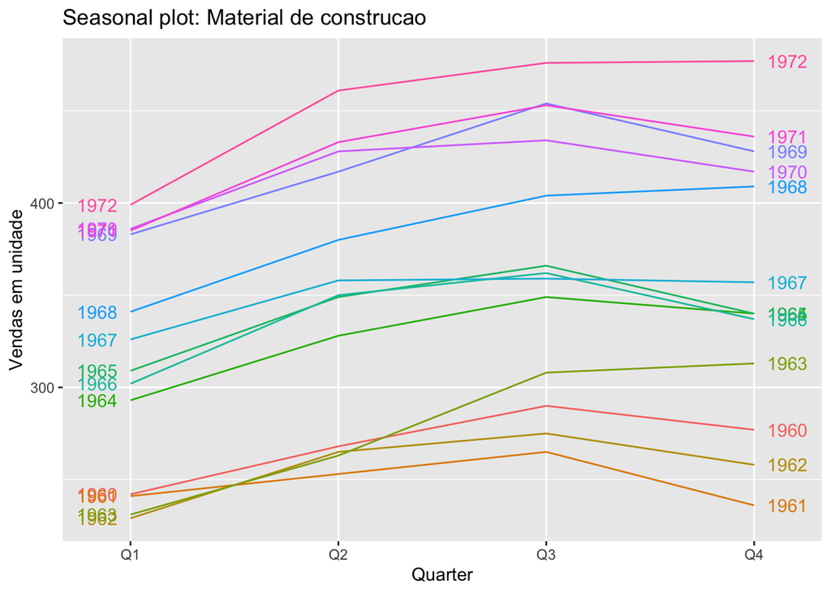

```r
ggseasonplot(y, year.labels=TRUE, year.labels.left=TRUE) + ylab("Vendas em unidade") +
  ggtitle("Seasonal plot: Material de construcao")
```

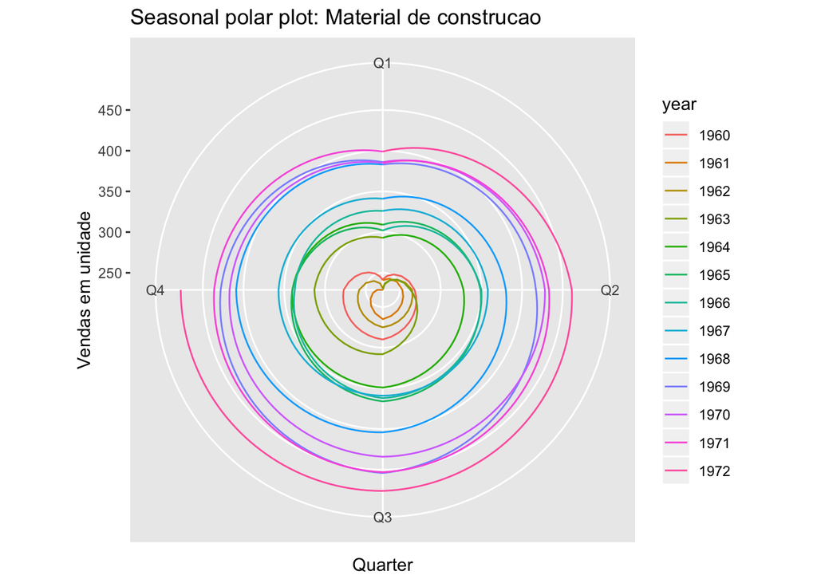

```r
ggseasonplot(y, polar=TRUE) + ylab("Vendas em unidade") + ggtitle("Seasonal polar plot: Material de construcao")
```

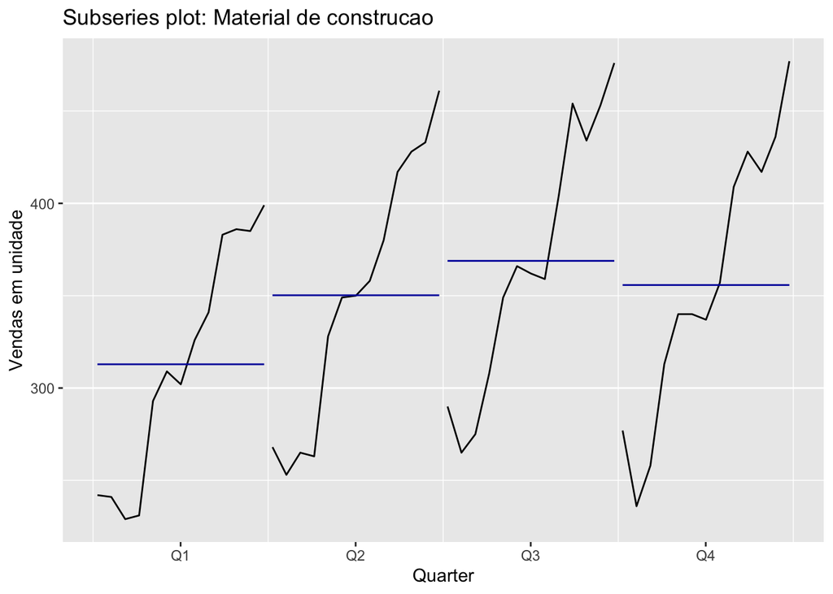

```r
ggsubseriesplot(y) + ylab("Vendas em unidade") + ggtitle("Subseries plot: Material de construcao")
```

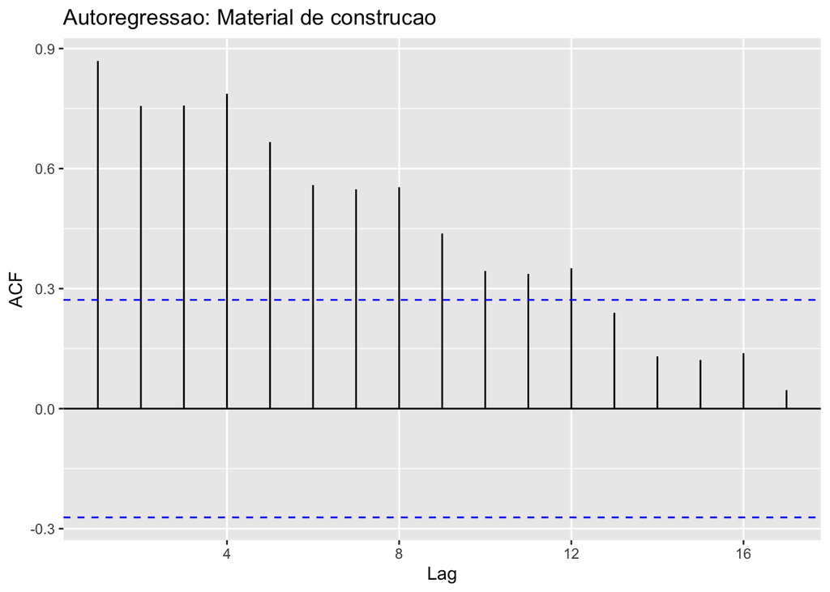

```r
ggAcf(y) + ggtitle("Autoregressao: Material de construcao")
```

## Metodos simples de previsao

Inicialmente, foram usados os métodos simples de previsão e aplicados na séria temporal completa (1960.1-1972.4). As previsoes sao apresentadas em gráficos.

funcao meanf(): as previsões são iguais ao valor médio da série temporal funcao naive(): as previsões são iguais ao último valor da série temporal funcao snaive(): as previsões se baseiam num modelo ARIMA (0,0,0) (0,1,0) m onde m é o período sazonal. funcao rwf(): previsões do tipo random walk são planas e iguais à última observação (igual a naive()). funcao rwf(drift=TRUE): Adicionando o termo de drift a previsao do tipo random walk, um padrão de tendência pode ser capturado.

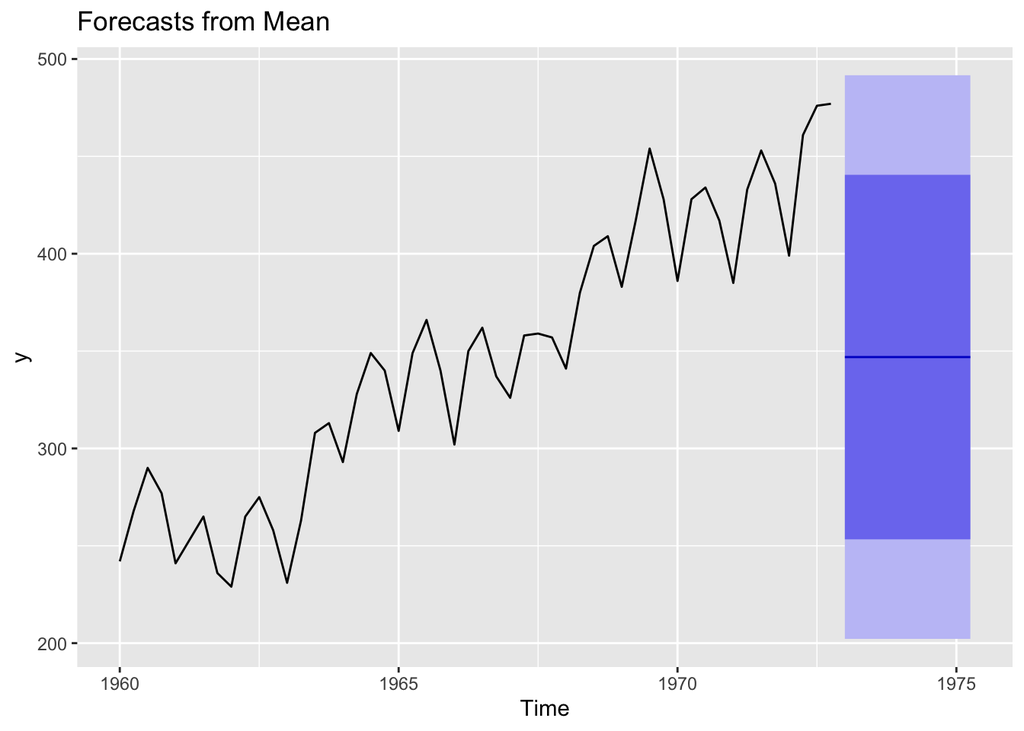

```r
meanf <- meanf(y)
autoplot(meanf)
```

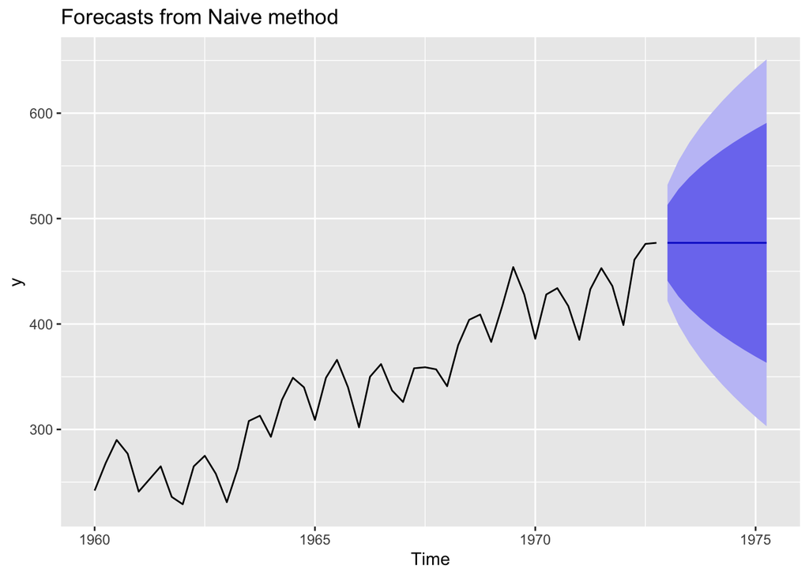

```r
naive <- naive(y)
autoplot(naive)
```

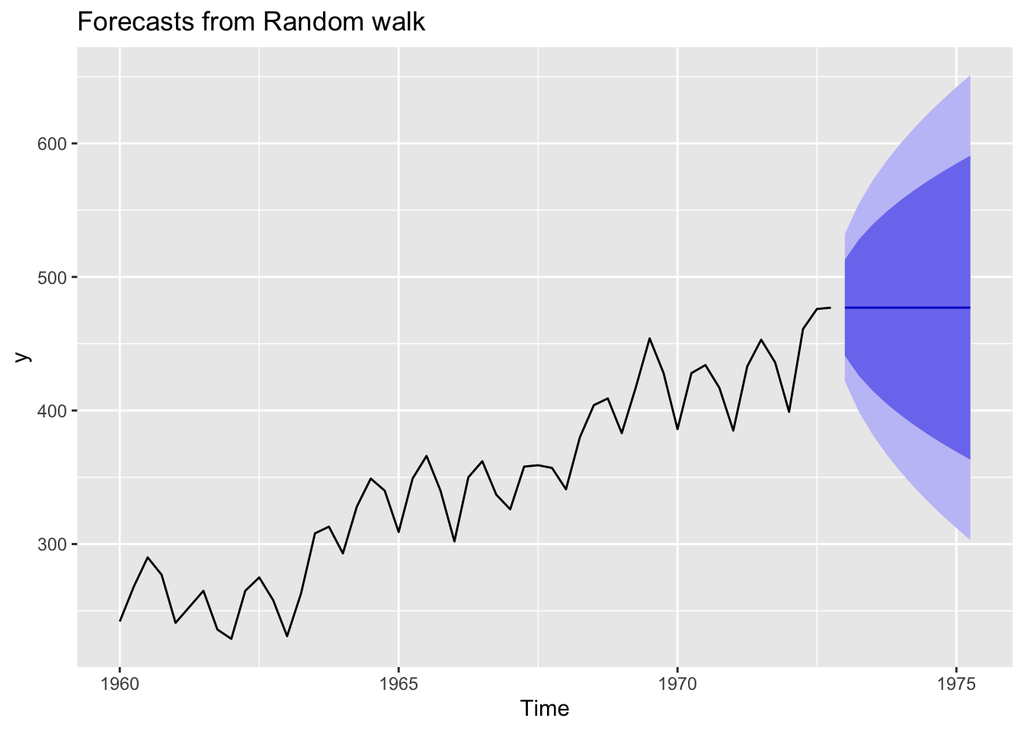

```r
rwf <- rwf(y)
autoplot(rwf)
```

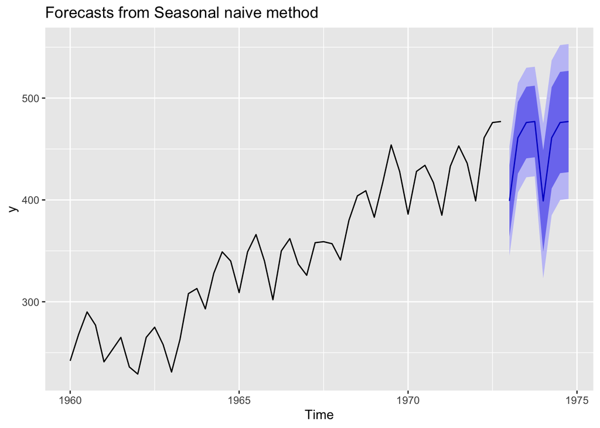

```r
snaive <- snaive(y)
autoplot(snaive)
```

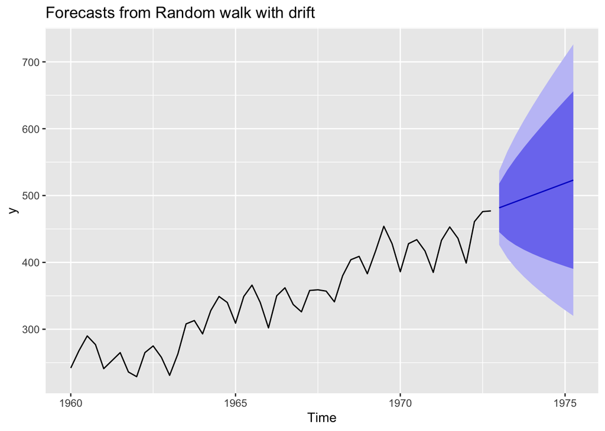

```r
rwf.drift <- rwf(y, drift=TRUE)
autoplot(rwf.drift)
```

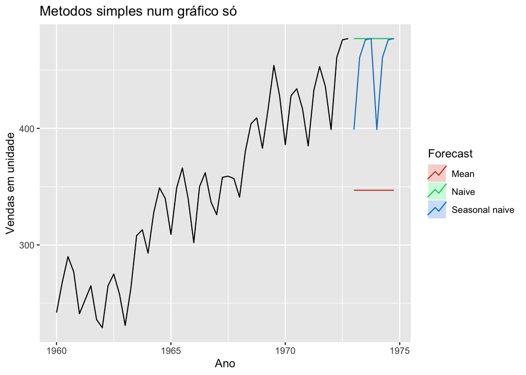

```r
autoplot(y) +
autolayer(meanf(y, h=8),series="Mean", PI=FALSE) + autolayer(naive(y, h=8), series="Naive", PI=FALSE) + autolayer(snaive(y, h=8),series="Seasonal naive", PI=FALSE) + ggtitle("Metodos simples num gráfico só") + xlab("Ano") + ylab("Vendas em unidade") + guides(colour=guide_legend(title="Forecast"))
```

## Separar a séria

```r
x <- window(y, start=1960, end=c(1970, 4))
x
```

```
##      Qtr1 Qtr2 Qtr3 Qtr4
## 1960  242  268  290  277
## 1961  241  253  265  236
## 1962  229  265  275  258
## 1963  231  263  308  313
## 1964  293  328  349  340
## 1965  309  349  366  340
## 1966  302  350  362  337
## 1967  326  358  359  357
## 1968  341  380  404  409
## 1969  383  417  454  428
## 1970  386  428  434  417
```

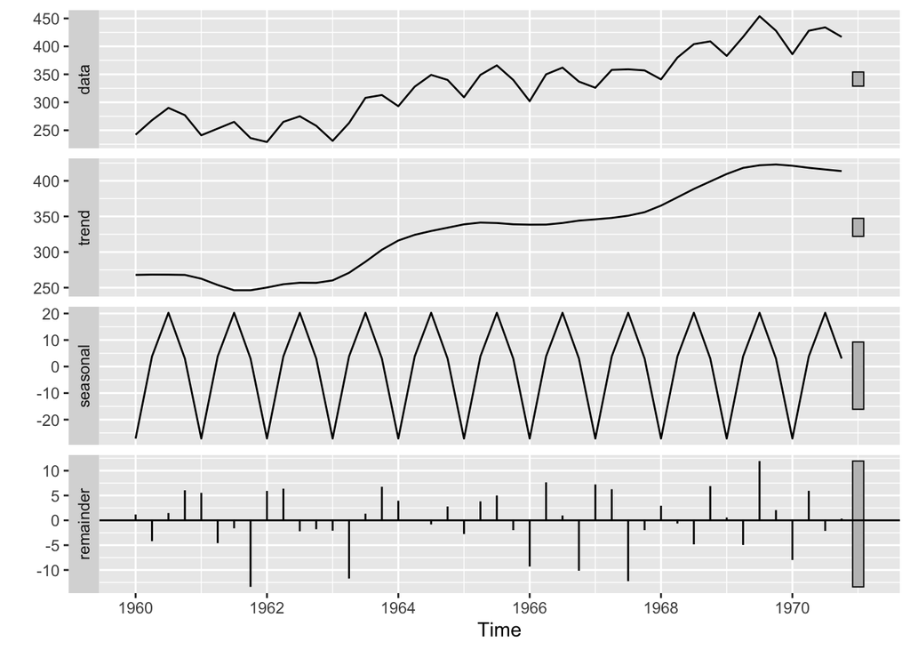

```r
descomp.x <- stl(x, s.window="periodic")
autoplot(descomp.x)
```

O grafico da descomposicao revela que se trata de uma sazonalidade de forma aditiva, ja que as inclinacoes sao reglares no grafico de “Seasonality” e nao aumentam de forma multiplicativa. A presenca de tendencia e sazonalidade faz que o modelo Holt Winters seja o mais apropriado para essa seria temporal. A previsao e feito para os dois anos seguidos como e pedido no exercicio.

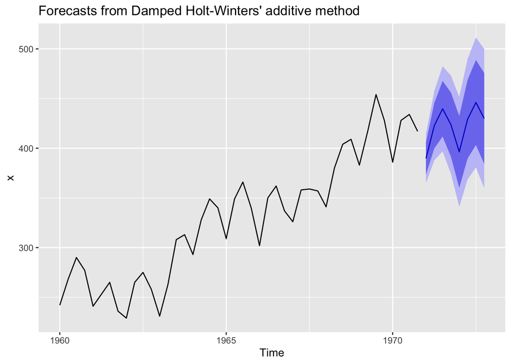

```r
hw.x <- hw(x, damped=TRUE, seasonal="additive")
forecast.hw.x <- forecast(hw.x, n.ahead = 8, forecast.interval = TRUE)
autoplot(forecast.hw.x)
```

Esses dados de previsao agora podem ser usados para os comprarar com os valores reais e avaliar a qualidade da previsao. Para isso, sao calculados os erros MAE, MSE, MAPE. Eles sao usados para comparar os ajustes de diferentes modelos de séries temporais. Valores menores indicam um melhor ajuste. A Média Porcentual Absoluta do Erro (MAPE - Mean Absolute Percentage Error) expressa a acurácia como uma porcentagem do erro. Como a MAPE é uma porcentagem, pode ser mais fácil de entender do que as outras estatísticas de medida de precisão. Por exemplo, se o MAPE for 5, em média, a previsão será de 5%. O Erro Absoluto Médio (MAE - Mean Absolute Error) expressa a acurácia nas mesmas unidades dos dados, o que ajuda a conceituar a quantidade de erro. O Erro Médio Quadrado (MSE - Mean Square Error) mede a acurácia dos valores das séries temporais ajustadas. Os outliers têm um efeito maior no MSE do que no MAE.

```r
ref <- window(y, start=1971, end=c(1972, 4))
ref
```

```
##      Qtr1 Qtr2 Qtr3 Qtr4
## 1971  385  433  453  436
## 1972  399  461  476  477
```

```r
accuracy(forecast.hw.x, ref)
```

```
##                      ME     RMSE       MAE         MPE     MAPE      MASE
## Training set  0.4080692 11.24971  9.004064 -0.03243558 2.834720 0.4111445
## Test set     17.8266604 23.95267 19.017176  3.82774632 4.136971 0.8683642
##                   ACF1 Theil's U
## Training set 0.1019294        NA
## Test set     0.3051515  0.665393
```

Decomposicao da seria total, de forma aditiva e multiplicativa.

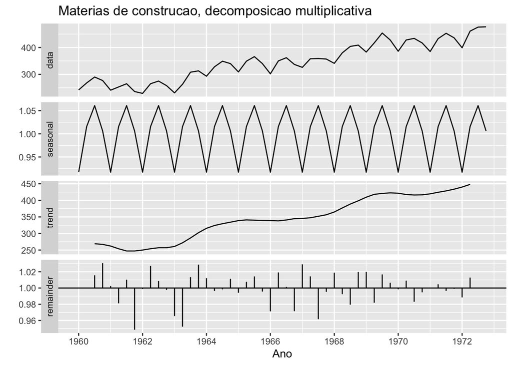

```r
y %>% decompose(type="multiplicative") %>% autoplot() + xlab("Ano") +
ggtitle("Materias de construcao, decomposicao multiplicativa")
```

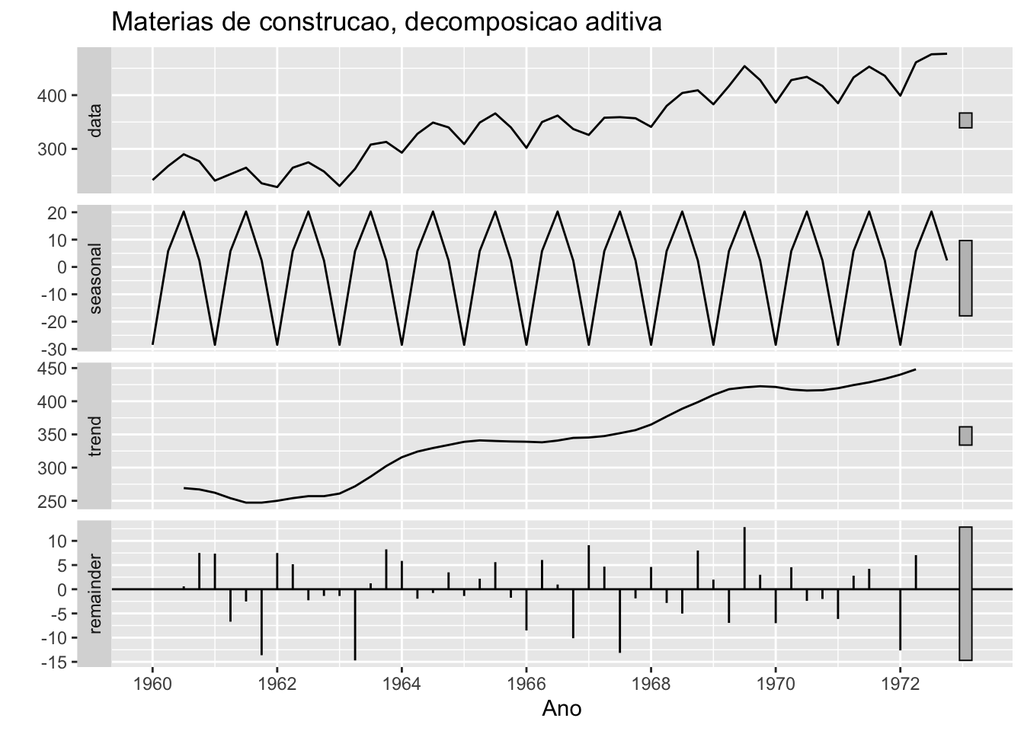

```r
y %>% decompose(type="additive") %>% autoplot() + xlab("Ano") +
ggtitle("Materias de construcao, decomposicao aditiva")
```

No seguinte, o modelo Holt Winters se vai aplicar para a séria temporal completa.

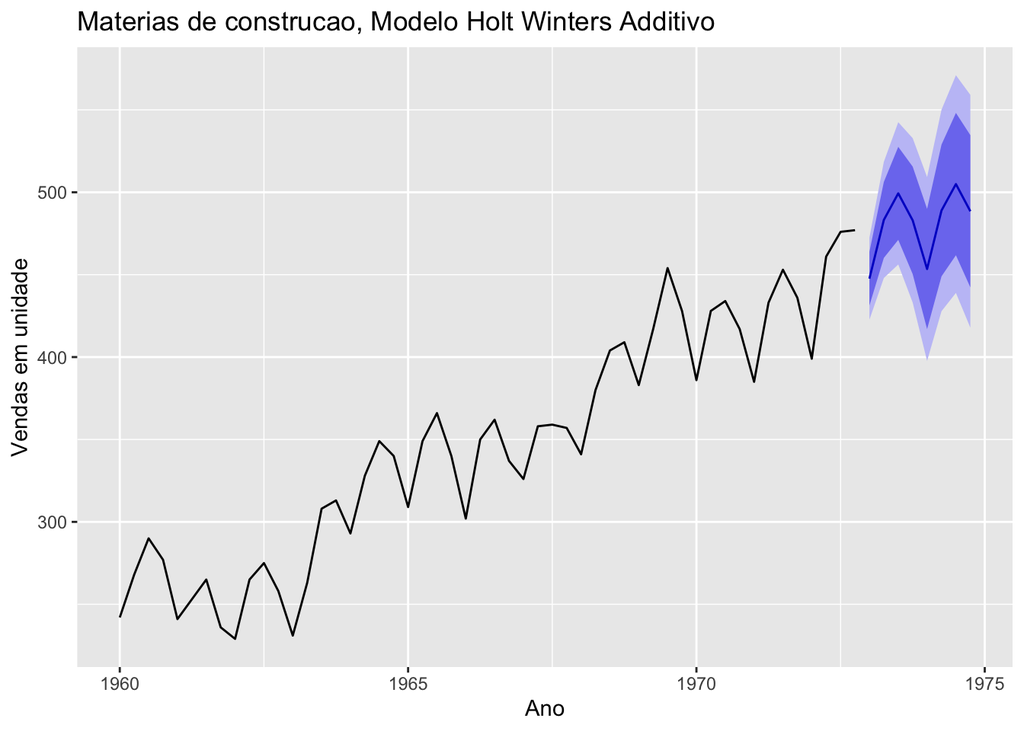

```r
library(seasonal)
hw.y <- hw(y, damped=TRUE, seasonal="additive")
forecast.hw.y <- forecast(hw.y, n.ahead = 8, forecast.interval = TRUE)
autoplot(forecast.hw.y) + xlab("Ano") + ylab("Vendas em unidade") +
ggtitle("Materias de construcao, Modelo Holt Winters Additivo ")
```

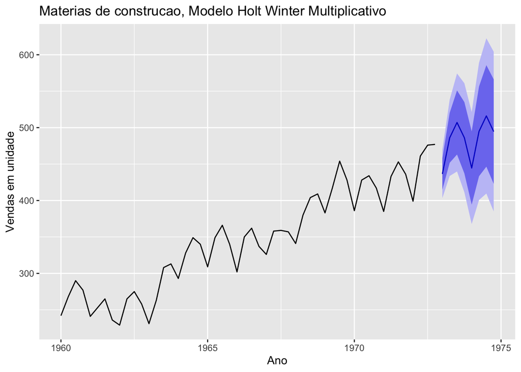

```r
hw.y.mul <- hw(y, damped=TRUE, seasonal="multiplicative")
forecast.hw.y.mul <- forecast(hw.y.mul, n.ahead = 8, forecast.interval = TRUE)
autoplot(forecast.hw.y.mul) + xlab("Ano") + ylab("Vendas em unidade") +
ggtitle("Materias de construcao, Modelo Holt Winter Multiplicativo")
```

## Criar outliers

Agora, se vao criar outliners para ver quais efeitos isso vai ter sobre as previsoes. Se cria um novo vetor, em qual podem-se trocar os valores originais por outliers. Primeiro, cria-se um outliner no meio da série, depois no final. Pose se observar que um outlier no meio tem um efeito mais drástico. Ele atrapalha muito na descomposicao do fator sazonal.

```r
y.outliers.a <- ts(material$value, frequency=4, start=c(1960, 1))
y.outliers.a[25] <- 2000
y.outliers.a
```

```
##      Qtr1 Qtr2 Qtr3 Qtr4
## 1960  242  268  290  277
## 1961  241  253  265  236
## 1962  229  265  275  258
## 1963  231  263  308  313
## 1964  293  328  349  340
## 1965  309  349  366  340
## 1966 2000  350  362  337
## 1967  326  358  359  357
## 1968  341  380  404  409
## 1969  383  417  454  428
## 1970  386  428  434  417
## 1971  385  433  453  436
## 1972  399  461  476  477
```

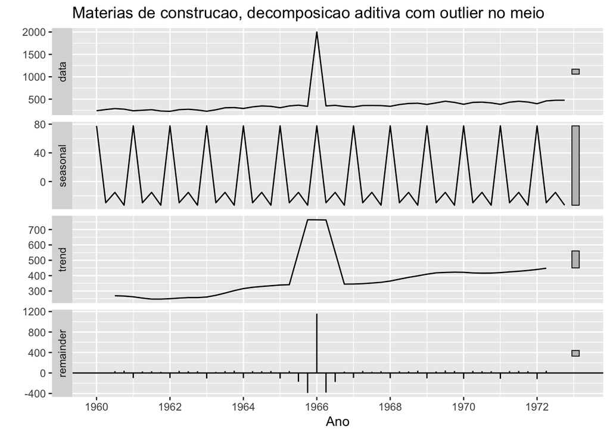

```r
y.outliers.a %>% decompose(type="additive") %>% autoplot() + xlab("Ano") +
ggtitle("Materias de construcao, decomposicao aditiva com outlier no meio")
```

```r
y.outliers.b <- ts(material$value, frequency=4, start=c(1960, 1))
y.outliers.b[52] <- 5
y.outliers.b
```

```
##      Qtr1 Qtr2 Qtr3 Qtr4
## 1960  242  268  290  277
## 1961  241  253  265  236
## 1962  229  265  275  258
## 1963  231  263  308  313
## 1964  293  328  349  340
## 1965  309  349  366  340
## 1966  302  350  362  337
## 1967  326  358  359  357
## 1968  341  380  404  409
## 1969  383  417  454  428
## 1970  386  428  434  417
## 1971  385  433  453  436
## 1972  399  461  476    5
```

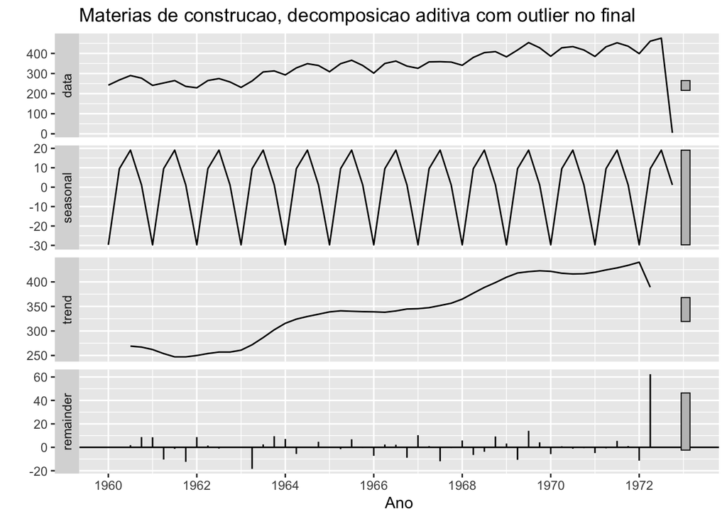

```r
y.outliers.b %>% decompose(type="additive") %>% autoplot() + xlab("Ano") +
ggtitle("Materias de construcao, decomposicao aditiva com outlier no final")
```

## Regressao linear

De igual forma, se pode usar um modelo de regressao para prognosticar dados. A existencia de tendencia e sazonalidade já se pode incluir no código. O resultado nao demostra grandes diferencias com o modelo additivo de Holt Winters.

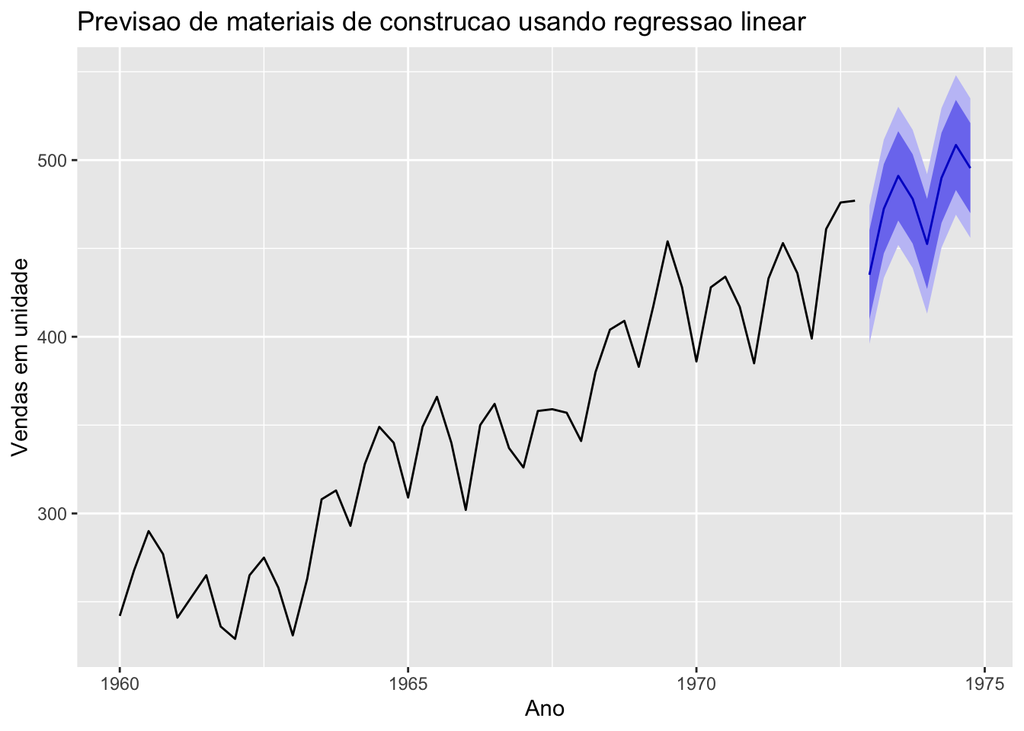

```r
y.regressao <- tslm(y ~ trend + season)
forecast.y.regressao <- forecast(y.regressao, h=8)
autoplot(forecast.y.regressao) +
  ggtitle("Previsao de materiais de construcao usando regressao linear") +
  xlab("Ano") + ylab("Vendas em unidade")
```